# Mixed model examples

## Load packages …

```r
## fitting
library(lme4)
library(glmmTMB)
```

```r
library(lattice)
## diagnostics etc.
library(broom.mixed)
library(DHARMa)
library(performance)
library(sjPlot)
library(dotwhisker)
##
library(ggplot2); theme_set(theme_bw())
library(cowplot)
```

## Examples

- Most examples here taken from [Vincent Zoonekynd’s page](http://zoonek2.free.fr/UNIX/48_R/14.html)
- See also [supplementary material from Bolker book chapter](http://bbolker.github.io/mixedmodels-misc/ecostats_chap.html) (source code [here](https://github.com/bbolker/mixedmodels-misc/blob/master/ecostats_chap.rmd))

## Formulae

| Formula | Meaning |
| --- | --- |
| `y ~ x` | No random effects |
| `y ~ x + (1\|g)` | The intercept is a random effect |
| `y ~ x + (1\|site/block)` | Nested random effects (block within site) |
| `y ~ x + (1\|site) + (1\|year)` | Crossed random effects |
| `y ~ x + (1\|site:block)` | Interaction (only block within site) |
| `y ~ x + site + (1\|site:block)` | Fixed site, random block within site |
| `y ~ x + (x\|g)` | Intercept and slope are random effects |
| `y ~ (x\|g)` | Zero slope on average (weird!) |
| `y ~ x + (1\|g)+(0+x\|g)` | Independent slope and intercept |

## Look at the data

- *Spaghetti plot*; alternatively `+facet_wrap(~Subject)`

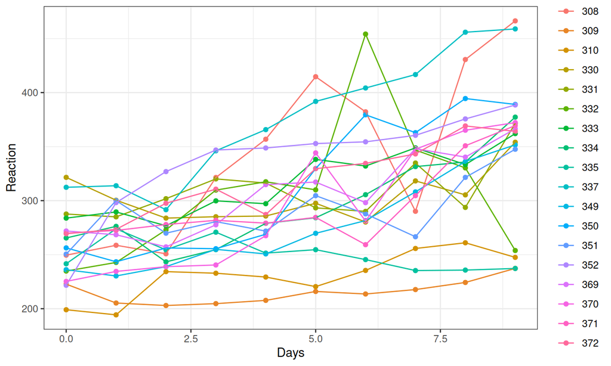

```r
print((q0 <- ggplot(sleepstudy, aes(Days, Reaction, colour = Subject))
    + geom_point()) + geom_line())
```

(Alternatives; connect, don’t colour; suppress legend; separate individuals into separate facets … for scatterplots, try `ggalt::geom_encircle()`. See examples [here](https://bbolker.github.io/goettingen_2019/notes/datavis.html) as well.)

## Basic model fits

```r
library(lme4)
## per-group fit (fixed)
lm1 <- lmList(Reaction~Days|Subject, data=sleepstudy)
## fixed effect
lm1B <- lm(Reaction~Days*Subject, data=sleepstudy)
## random intercept
lm2 <- lmer(Reaction~Days+(1|Subject), data=sleepstudy)
## random slopes
lm3 <- lmer(Reaction~Days+(1+Days|Subject), data=sleepstudy)
```

Use *random slopes* when feasible, i.e. when some individuals are measured on more than 1 day (Schielzeth and Forstmeier 2009)

## Compute predictions

```r
pp <- expand.grid(Days=0:9, Subject=levels(sleepstudy$Subject))
pp <- (pp
  |> cbind(pred_int = predict(lm2, newdata=pp))
  |> cbind(pred_int_slope = predict(lm3, newdata=pp))
  |> cbind(pred_fixed = predict(lm1B, newdata=pp))
  |> tidyr::pivot_longer(starts_with("pred"))
)
```

## plot predictions

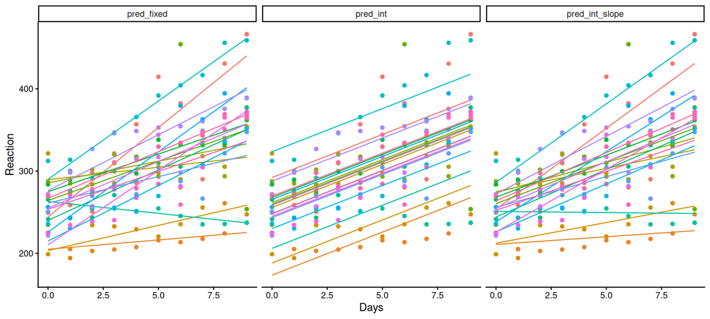

```r
theme_set(theme_classic()+theme(legend.position="none"))
q0+geom_line(data=pp, aes(y=value)) + facet_wrap(~name)
```

## diagnostics

- `DHARMa::simulateResiduals()`
- `performance::check_model()`

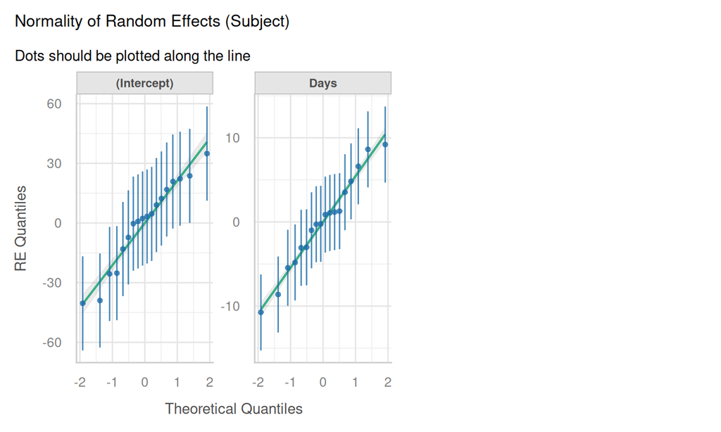

## coefficient plots

Use `broom.mixed` (in conjunction with `dotwhisker::dwplot`)

- use `tidy` directly for more control (`?tidy.merMod`)
- may want to specify `effects="fixed"`, `conf.int=TRUE`, `conf.method="profile"` (for CIs on random effects parameters)

```r
tt <- tidy(lm3, conf.int=TRUE, conf.method="profile")
```

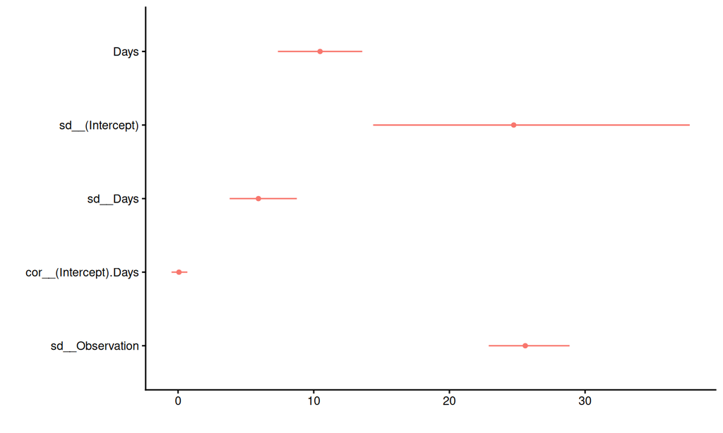

```r
dwplot(tt)
```

## random effects plots

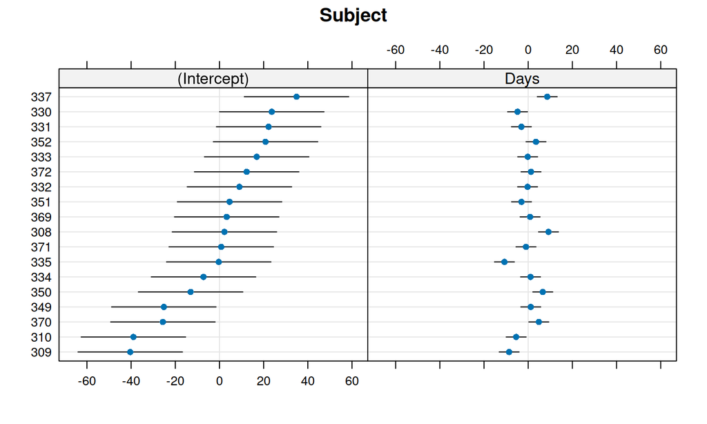

```r
lattice::dotplot(ranef(lm3))
```

Or `sjPlot::plot_model()`

## post-hoc stuff

`emmeans`, `effects`, `car::Anova()`, `drop1`, etc. all work …

## model choice considerations

- what is the **maximal model**?
- Which effects vary *within* which groups?
- If effects don’t vary within groups, then we *can’t* estimate among-group variation in the effect
  - convenient
  - maybe less powerful (among-group variation is lumped into residual variation)
- e.g. female rats exposed to different doses of radiation, multiple pups per mother, multiple measurements per pup (labeled by time). Maximal model … ?

Maximal model **often won’t actually work**

e.g.

- *Culcita* (coral-reef) example: randomized-block design, so each treatment (none/crabs/shrimp/both) is repeated in every block; thus `(treat|block)` is maximal
- CBPP data: each herd is measured in every period, so in principle we could use `(period|herd)`, not just `(1|herd)`

## Random-slopes models

- what does `(x|g)` (or `(1+x|g)` really do?
- both intercept (baseline) and slope vary across groups
- estimates **bivariate** zero-centered distribution:

\[ (\textrm{intercept}, \textrm{slope}) = \textrm{MVN}\left(\boldsymbol 0, \left[ \begin{array}{cc} \sigma^2_{\textrm{int}} & \sigma_{\textrm{int},\textrm{slope}} \\ \sigma_{\textrm{int},\textrm{slope}} & \sigma^2_{\textrm{slope}} \end{array} \right] \right) \]

## `equatiomatic` package

```r
equatiomatic::extract_eq(lm3)
```

\[ \begin{aligned} \operatorname{Reaction}_{i} &\sim N \left(\alpha_{j[i]} + \beta_{1j[i]}(\operatorname{Days}), \sigma^2 \right) \\ \left( \begin{array}{c} \begin{aligned} &\alpha_{j} \\ &\beta_{1j} \end{aligned} \end{array} \right) &\sim N \left( \left( \begin{array}{c} \begin{aligned} &\mu_{\alpha_{j}} \\ &\mu_{\beta_{1j}} \end{aligned} \end{array} \right) , \left( \begin{array}{cc} \sigma^2_{\alpha_{j}} & \rho_{\alpha_{j}\beta_{1j}} \\ \rho_{\beta_{1j}\alpha_{j}} & \sigma^2_{\beta_{1j}} \end{array} \right) \right) \text{, for Subject j = 1,} \dots \text{,J} \end{aligned} \]

## What is a practical model?

- Avoid **singular** fits
- singular = zero variances, +/- 1 correlations
- More subtle for larger models: use `isSingular()`

## How to simplify?

- remove random effects
- simplify random effects (Bates et al. 2015; Matuschek et al. 2017; Barr et al. 2013)
  - drop slopes
  - force correlations to zero (use `1+x||g` to fit intercept and slope independently)
  - structured random effects (diagonal, compound symmetric …)

## Convergence failures

- convergence failures are common
- what do they really mean? how to fix them? when can they be ignored?
- **approximate** test that gradient=0 and curvature is correct
- scale and center predictors; simplify model
- use `?allFit` to see whether different optimizers give sufficiently similar answers
  - `$fixef`, etc.: are answers sufficiently similar?
  - `$llik`: how similar is goodness-of-fit?

## allFit

```r
m1 <- lmer(Reaction ~ Days + (Days|Subject), sleepstudy)
aa <- allFit(m1)
```

```
## bobyqa : [OK]
## Nelder_Mead : [OK]
## nlminbwrap : [OK]
## nmkbw : [OK]
## optimx.L-BFGS-B : [OK]
## nloptwrap.NLOPT_LN_NELDERMEAD : [OK]
## nloptwrap.NLOPT_LN_BOBYQA : [OK]
```

```r
ss <- summary(aa)
names(ss)
```

```
## [1] "which.OK" "msgs"     "fixef"    "llik"     "sdcor"    "theta"    "times"
## [8] "feval"
```

```r
ss$fixef
```

```
##                               (Intercept)     Days
## bobyqa                           251.4051 10.46729
## Nelder_Mead                      251.4051 10.46729
## nlminbwrap                       251.4051 10.46729
## nmkbw                            251.4051 10.46729
## optimx.L-BFGS-B                  251.4051 10.46729
## nloptwrap.NLOPT_LN_NELDERMEAD    251.4051 10.46729
## nloptwrap.NLOPT_LN_BOBYQA        251.4051 10.46729
```

## allFit plot

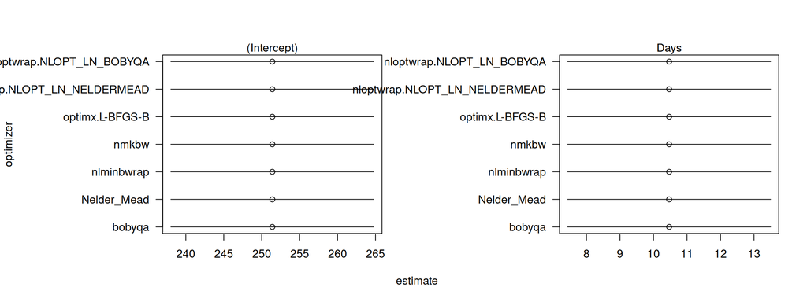

```r
source("https://raw.githubusercontent.com/lme4/lme4/refs/heads/master/misc/plot_allFit.R")
par(las=1); tpar(fmar = c(1,12,1,1))
plot(aa, flip = TRUE)
```

## GLMMs: integration techniques

- PQL, Laplace, adaptive Gauss-Hermite quadrature (AGHQ)
- fast/flexible/inaccurate \(\to\) slow/inflexible/accurate
- **amount of data per group** is what matters
  - number of points, info per point (binary vs count)
- set `nAGQ=` to a larger value (1=Laplace; 25 should be more than enough)

## GLMMs: more details

- `glmer` pretty reliable
- `glmmTMB` more flexible, faster on extended models (NB etc.)

## Other resources

- Mixed Models task view
- the [GLMM FAQ](https://bbolker.github.io/mixedmodels-misc/glmmFAQ.html)

## References

Barr, Dale J., Roger Levy, Christoph Scheepers, and Harry J. Tily. 2013. “Random Effects Structure for Confirmatory Hypothesis Testing: Keep It Maximal.” *Journal of Memory and Language* 68 (3): 255–78. https://doi.org/10.1016/j.jml.2012.11.001.

Bates, Douglas, Reinhold Kliegl, Shravan Vasishth, and Harald Baayen. 2015. “Parsimonious Mixed Models.” *arXiv:1506.04967 [Stat]*, June. http://arxiv.org/abs/1506.04967.

Matuschek, Hannes, Reinhold Kliegl, Shravan Vasishth, Harald Baayen, and Douglas Bates. 2017. “Balancing Type I Error and Power in Linear Mixed Models.” *Journal of Memory and Language* 94: 305–15. https://doi.org/10.1016/j.jml.2017.01.001.

Schielzeth, Holger, and Wolfgang Forstmeier. 2009. “Conclusions Beyond Support: Overconfident Estimates in Mixed Models.” *Behavioral Ecology* 20 (2): 416–20. https://doi.org/10.1093/beheco/arn145.